# M05_activity

Hannah Valenty

2024-07-19

Task 1

```r
library(dplyr)
```

```r
library(ggplot2)
df <- read.csv('Books_Data_Clean.csv')
head(df)
```

```
##   index Publishing.Year                       Book.Name
## 1     0            1975                         Beowulf
## 2     1            1987                Batman: Year One
## 3     2            2015               Go Set a Watchman
## 4     3            2008 When You Are Engulfed in Flames
## 5     4            2011        Daughter of Smoke & Bone
## 6     5            2015                       Red Queen
##                                                            Author language_code
## 1                                          Unknown, Seamus Heaney         en-US
## 2 Frank Miller, David Mazzucchelli, Richmond Lewis, Dennis O'Neil           eng
## 3                                                      Harper Lee           eng
## 4                                                   David Sedaris         en-US
## 5                                                    Laini Taylor           eng
## 6                                                Victoria Aveyard           eng
##   Author_Rating Book_average_rating Book_ratings_count         genre
```

[output cut: 20 more lines]

Visualize data

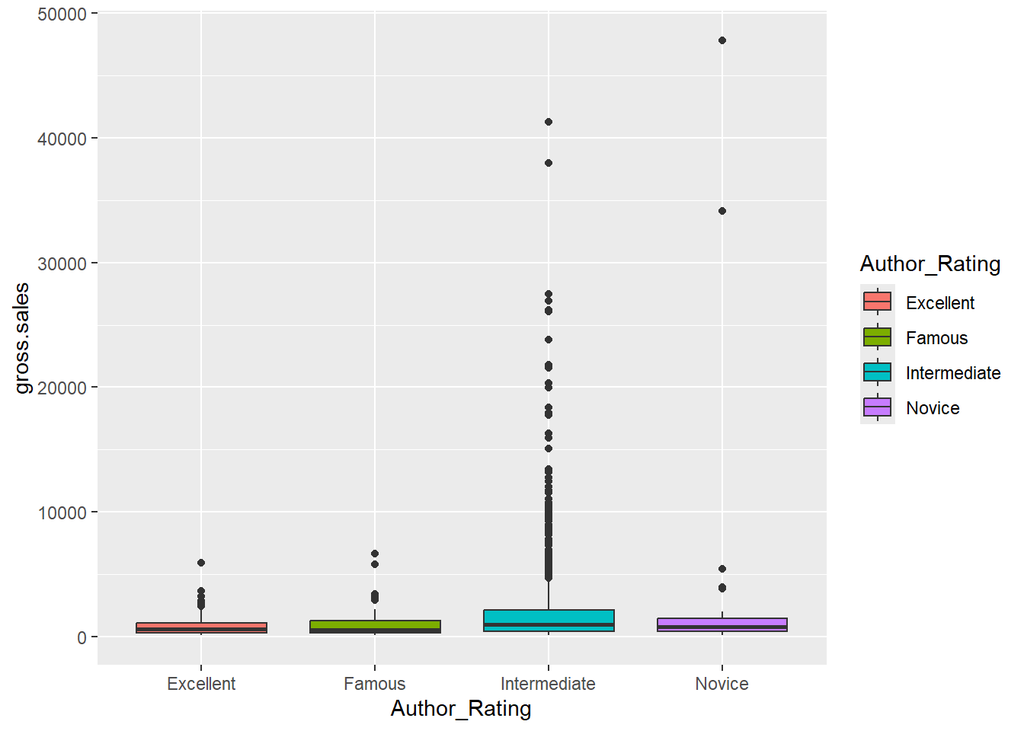

```r
ggplot(df, aes(x=Author_Rating, y=gross.sales, fill = Author_Rating))+
  geom_boxplot()
```

Zoom In

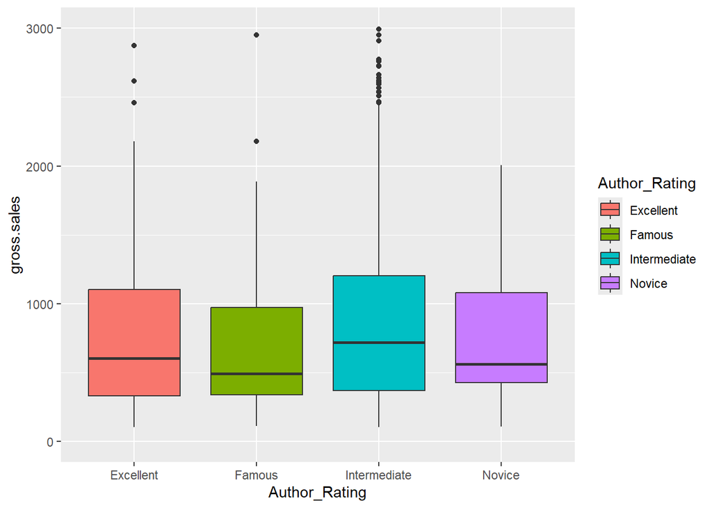

```r
ggplot(df, aes(x=Author_Rating, y=gross.sales, fill = Author_Rating))+
  geom_boxplot()+
  ylim(0, 3000)
```

ANOVA Test

```r
anova <- aov(gross.sales~Author_Rating, data=df)
summary(anova)
```

```
##                 Df    Sum Sq   Mean Sq F value   Pr(>F)
## Author_Rating    3 7.881e+08 262704446   17.75 3.03e-11 ***
## Residuals     1066 1.578e+10  14803673
## ---
## Signif. codes:  0 '***' 0.001 '**' 0.01 '*' 0.05 '.' 0.1 ' ' 1
```

p-value = 3.03e-11 (very close to zero), therefore reject the null hypothesis.

Hypotheses Tests

```r
TukeyHSD(anova, conf.level = 0.95)
```

```
##   Tukey multiple comparisons of means
##     95% family-wise confidence level
##
## Fit: aov(formula = gross.sales ~ Author_Rating, data = df)
##
## $Author_Rating
##                             diff        lwr      upr     p adj
## Famous-Excellent        373.6263 -1082.4068 1829.659 0.9119276
## Intermediate-Excellent 1679.8549  1025.9664 2333.743 0.0000000
## Novice-Excellent       3034.1830  1153.2751 4915.091 0.0002092
## Intermediate-Famous    1306.2286  -110.1401 2722.597 0.0829421
## Novice-Famous          2660.5567   398.6229 4922.491 0.0134907
## Novice-Intermediate    1354.3281  -496.0455 3204.702 0.2358077
```

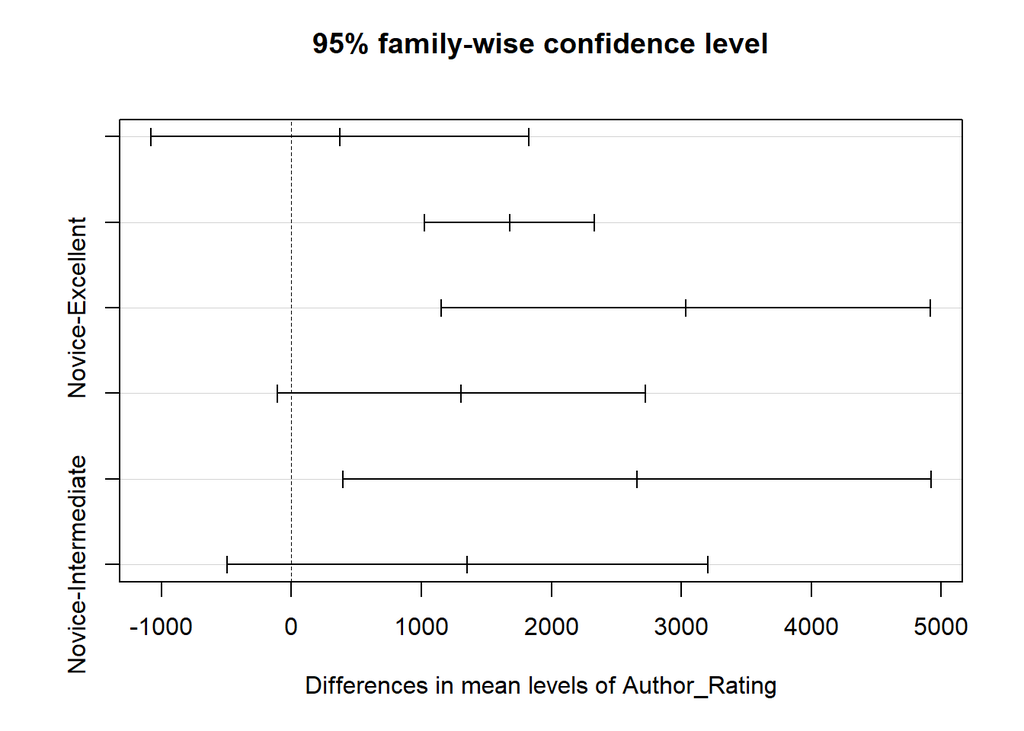

```r
plot(TukeyHSD(anova, conf.level = 0.95))
```

Rating Pairs & their Intervals

- Famous-Excellent (-1082.4068, 1829.659) $\rightarrow$ crosses zero (inconclusive)
- Intermediate-Excellent (1025.9664, 2333.743) $\rightarrow$ both positive (Intermediate larger)
- Novice-Excellent (1153.2751, 4915.091) $\rightarrow$ both positive (Novice larger)
- Intermediate-Famous (-110.1401, 2722.597) $\rightarrow$ crosses zero (inconclusive)
- Novice-Famous (398.6229, 4922.491) $\rightarrow$ both positive (Novice larger)
- Novice-Intermediate (-496.0455, 3204.702) $\rightarrow$ crosses zero (inconclusive)

Base on the analysis above we can conclude that there are differences across the rating types. Based on further statistical evidence it can be determined that:

- Intermediate is greater than Excellent
- Novice is greater than Excellent
- Novice is greater than Famous

Task 2

To test the linear relationships of all variables against gross.sales, I would begin by producing a set of scatterplots for each variable pair. We could add the linear model line within the plots to get an even clearer view. Check the residual values for each relationship and if they fall below a threshold we can consider the strength of the linear relationships (close to -1 and 1 are strong, and close to 0 is weak).